# Econometrics

TA Session 6

Lucia Sauer

*Barcelona School of Economics*

lucia.sauer@bse.eu

2025-11-11

## Planification — 2° Part

**TA6 — RCTs**

**TA7 — Matching**

**TA8 — Instrumental Variables**  
📆 Hand in Assignment 6 by **18th Nov**

**TA9 — Regression Discontinuity**  
📆 Hand in Assignment 7 by **27th Nov**

**TA10 — Difference-in-Differences**  
📆 Hand in Assignment 8 by **2nd Dec**

## Today

1. **Potential outcomes** — the fundamental problem of causality *(smoking & birthweight)*
2. **Randomization** — why it solves the problem
3. **An RCT in a ride-hailing app** — design, estimation, balance, covariates, heterogeneity

📓 Everything in **TA6.ipynb** (the data are simulated inside the notebook)

# 1 · Potential outcomes

## Potential outcomes

$$\begin{array}{rcl}
D_i \in \{0,1\} & \qquad & \text{treatment indicator} \\[2pt]
Y_i(1) & & \text{potential outcome } \textbf{with} \text{ treatment} \\[2pt]
Y_i(0) & & \text{potential outcome } \textbf{without} \text{ treatment} \\[2pt]
\tau_i = Y_i(1) - Y_i(0) & & \text{individual causal effect}
\end{array}$$

What we observe:

$$Y_i \;=\; D_i\,Y_i(1) + (1-D_i)\,Y_i(0) \;=\; \begin{cases} Y_i(1) & \text{if } D_i = 1 \\ Y_i(0) & \text{if } D_i = 0 \end{cases}$$

**The fundamental problem of causal inference**

We **never** observe both $Y_i(1)$ and $Y_i(0)$ for the same person: causality is a **missing data** problem.

## Example: does smoking during pregnancy reduce birthweight?

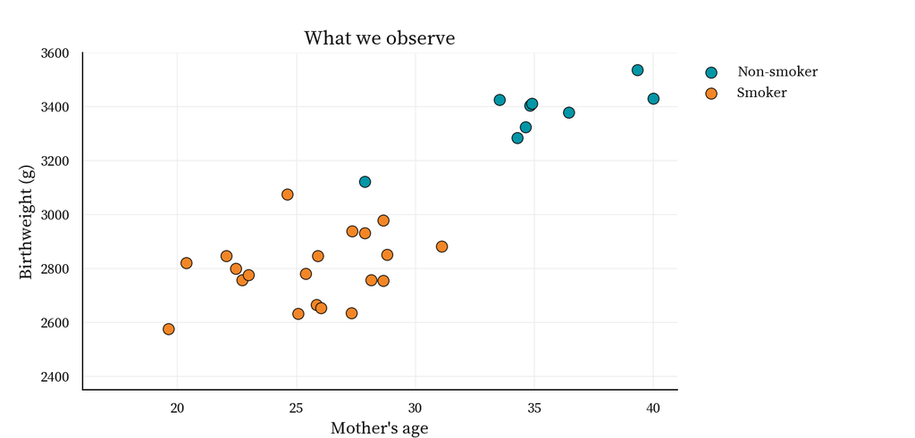

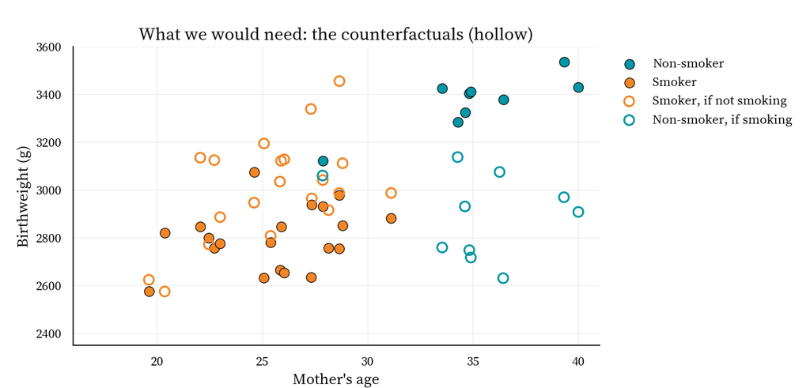

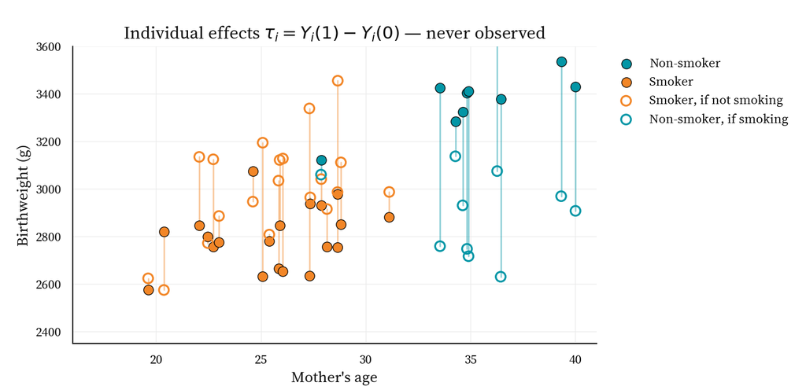

Each vertical segment is one $\tau_i$. We only ever see **one end** of it.

## Two averages of $\tau_i$: ATE and ATT

$$\text{ATE} = E[Y(1) - Y(0)] \qquad\qquad \text{ATT} = E[Y(1) - Y(0) \mid D = 1]$$

- **ATE**: average effect over **everyone**. *“What if all mothers smoked vs. none?”*
- **ATT**: average effect over the **treated** only. *“How much lighter are smokers’ babies because their mothers smoked?”*

What does the naive comparison of means estimate?

$$\underbrace{E[Y \mid D = 1] - E[Y \mid D = 0]}_{\text{naive comparison}} \;=\; \underbrace{E[Y(1) - Y(0) \mid D = 1]}_{\text{ATT}} \;+\; \underbrace{E[Y(0) \mid D = 1] - E[Y(0) \mid D = 0]}_{\text{selection bias}}$$

**Age is a confounder:** younger mothers smoke more **and** have lighter babies anyway ⇒ selection bias ≠ 0, so the naive comparison is neither the ATT nor the ATE.

# 2 · Randomization

## Randomization kills selection bias

If $D_i$ is assigned by a **coin flip**, it cannot depend on anything about the mother, observed or not:

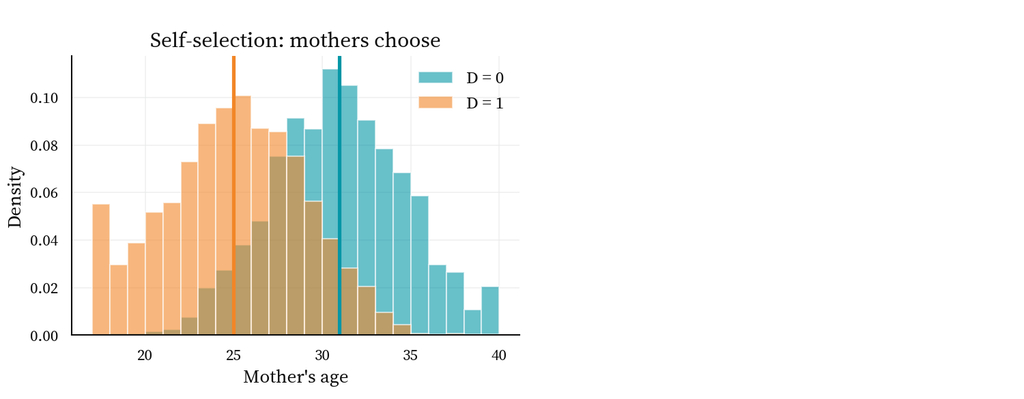

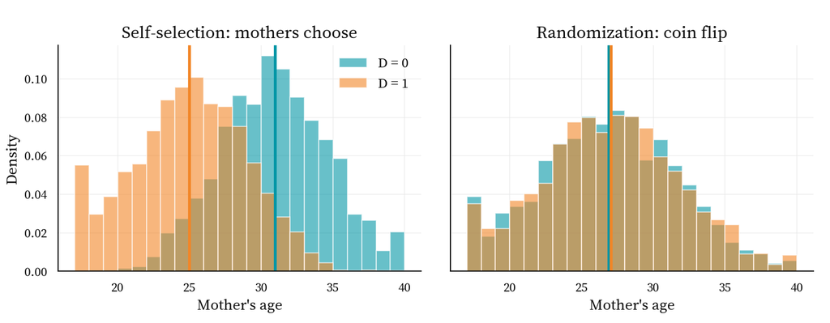

$$\begin{aligned}
\big(Y(1), Y(0)\big) \perp\!\!\!\perp D \;&\Longrightarrow\; \underbrace{E[Y(0) \mid D = 1] - E[Y(0) \mid D = 0]}_{\text{selection bias} \;=\; 0} \\[2pt]
&\Longrightarrow\; E[Y \mid D = 1] - E[Y \mid D = 0] \;=\; \text{ATT} \;=\; \text{ATE}
\end{aligned}$$

**Caveat**

Here randomization is **not an option**: assigning pregnant women to smoke would be **unethical** (and infeasible). For questions like this we need **observational** methods: matching, IV, RDD, DiD (the next TAs).

# 3 · An RCT in a ride-hailing app

## The case: a new, cheaper option in the app

*Ryde*, a (fictional) ride-hailing app, wants to add **one** new option to the menu: **“Wait & Save”**: ~25% cheaper if you accept being picked up in 10–15 minutes.

A · Control (D = 0)

9:41

Plaça de Catalunya

Sagrada Família

Choose a ride

**Economy**4 min · 4 seats

€12.40

**Comfort**5 min · newer cars

€15.90

**XL**7 min · 6 seats

€21.10

💳 Visa •••• 4242

Request ride

B · Treatment (D = 1)

9:41

Plaça de Catalunya

Sagrada Família

Choose a ride

**Economy**4 min · 4 seats

€12.40

**Comfort**5 min · newer cars

€15.90

**XL**7 min · 6 seats

€21.10

**Wait & SaveNEW**Pick-up in 10–15 min

€9.30

💳 Visa •••• 4242

Request ride

**Hypothesis:** **IF** we add an option **“Wait & Save”** **THEN** price-sensitive users who today take the bus or walk will now request a ride bringing more **revenue**.

## Designing the experiment

- **Outcome** $Y_i$: **revenue** from user $i$ in the 4 weeks of the test.
- **Treatment** $D_i = 1$ if user $i$ sees app **B** (with “Wait & Save”), $D_i = 0$ if app **A** (current menu).
- **Units:** active users, each randomly assigned to A or B with probability ½ (a coin flip per user).

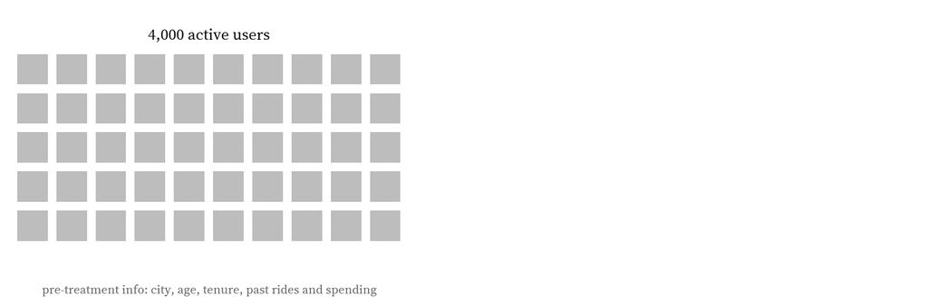

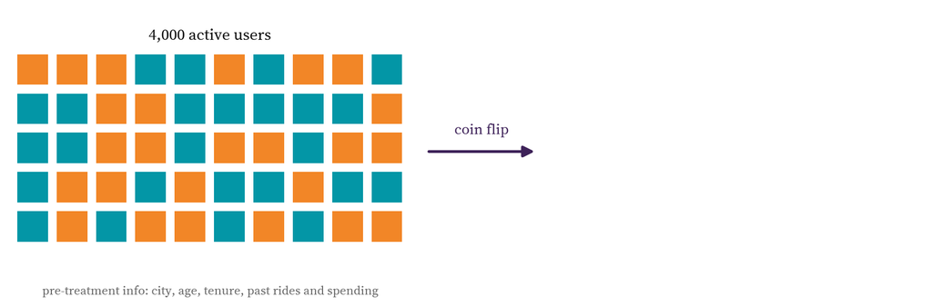

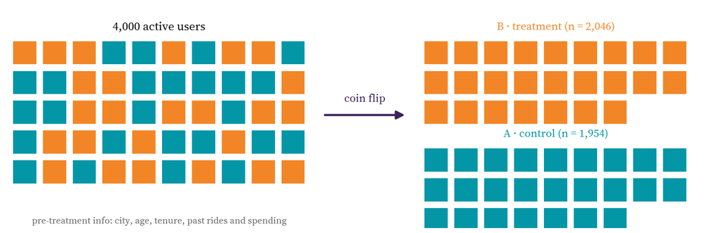

# 4 · Estimation

## The data

We simulate the experiment (code in the notebook) for 4,000 users. Relevant variables:

- `revenue_post`: $Y_i$, revenue (€) from user $i$ during the 4 weeks of the test
- `treat`: $D_i$, equal to 1 if app **B** (with “Wait & Save”), 0 if app **A**
- `city`, `age`, `tenure` (months on the app), `rides_pre`, `revenue_pre` (rides and € in the 4 weeks **before**): pre-treatment covariates $X_i$

```python
app[["user_id", "city", "age", "tenure", "rides_pre", "revenue_pre", "treat", "revenue_post"]].head()
```

|  | user_id | city | age | tenure | rides_pre | revenue_pre | treat | revenue_post |
| --- | --- | --- | --- | --- | --- | --- | --- | --- |
| 0 | 1 | Madrid | 37 | 15 | 5 | 48.86 | 0 | 9.25 |
| 1 | 2 | Madrid | 33 | 35 | 7 | 83.38 | 0 | 114.59 |
| 2 | 3 | London | 35 | 9 | 6 | 117.30 | 1 | 115.93 |
| 3 | 4 | Madrid | 18 | 11 | 0 | 0.00 | 1 | 12.67 |
| 4 | 5 | London | 33 | 27 | 15 | 329.65 | 1 | 270.34 |

## ATE = difference in means

Randomization ⇒ no selection bias ⇒ $\;\text{ATE} = E[Y \mid D = 1] - E[Y \mid D = 0]$, estimated by $\;\widehat{\text{ATE}} = \bar Y_1 - \bar Y_0$.

$$\begin{gathered}
H_0:\ E[Y \mid D = 1] = E[Y \mid D = 0] \qquad\quad H_a:\ E[Y \mid D = 1] \neq E[Y \mid D = 0] \\[6pt]
t = \frac{\bar Y_1 - \bar Y_0}{\sqrt{s_1^2/n_1 + s_0^2/n_0}} \;\overset{H_0}{\approx}\; N(0,1)
\end{gathered}$$

Welch two-sample $t$-test (unequal variances): reject $H_0$ at 5% if $|t| > 1.96$.

```python
y1 = app.loc[app.treat == 1, "revenue_post"]          # D = 1 (app B)
y0 = app.loc[app.treat == 0, "revenue_post"]          # D = 0 (app A)
print(f"mean(D=1) = {y1.mean():.2f}   mean(D=0) = {y0.mean():.2f}   difference = {y1.mean() - y0.mean():.2f}")
res = stats.ttest_ind(y1, y0, equal_var=False)          # Welch t-test
print(f"t = {res.statistic:.3f}   p-value = {res.pvalue:.4f}   df = {res.df:.1f}")
```

```
mean(D=1) = 60.88   mean(D=0) = 57.65   difference = 3.23
t = 1.612   p-value = 0.1070   df = 3996.9
```

$t = 1.61$, $\;p = 0.107$ ⇒ we **cannot reject** $H_0$ at 5%: the estimate is positive, but too noisy.

## … which is the same as a regression on $D$

$$\texttt{revenue}\_\texttt{post}_i = \beta_0 + \beta_1 D_i + \varepsilon_i$$

OLS Regression Results

| Dep. Variable: | revenue_post | R-squared: | 0.001 |
| --- | --- | --- | --- |
| Model: | OLS | Adj. R-squared: | 0.000 |
| Method: | Least Squares | F-statistic: | 2.599 |
| Date: | Mon, 09 Nov 2026 | Prob (F-statistic): | 0.107 |
| Time: | 21:08:30 | Log-Likelihood: | -22276. |
| No. Observations: | 4000 | AIC: | 4.456e+04 |
| Df Residuals: | 3998 | BIC: | 4.457e+04 |
| Df Model: | 1 |  |  |
| Covariance Type: | HC1 |  |  |

|  | coef | std err | z | P>\|z\| | [0.025 | 0.975] |
| --- | --- | --- | --- | --- | --- | --- |
| Intercept | 57.6523 | 1.389 | 41.513 | 0.000 | 54.930 | 60.374 |
| treat | 3.2309 | 2.004 | 1.612 | 0.107 | -0.697 | 7.159 |

| Omnibus: | 2005.560 | Durbin-Watson: | 2.049 |
| --- | --- | --- | --- |
| Prob(Omnibus): | 0.000 | Jarque-Bera (JB): | 14276.113 |
| Skew: | 2.303 | Prob(JB): | 0.00 |
| Kurtosis: | 11.028 | Cond. No. | 2.65 |

Notes:  
[1] Standard Errors are heteroscedasticity robust (HC1)

## Are treatment and control truly random?

If randomization worked, B and A look alike **before** the test. For each pre-treatment covariate $X_k$:

$$H_0:\ E[X_k \mid D = 1] = E[X_k \mid D = 0] \qquad t_k = \frac{\bar X_{k,1} - \bar X_{k,0}}{\sqrt{s_{k,1}^2/n_1 + s_{k,0}^2/n_0}}$$

| $X_k$ | $\bar X_{k,1}$ | $\bar X_{k,0}$ | Diff. | $t_k$ | p |
| --- | --- | --- | --- | --- | --- |
| Age | 33.767 | 33.912 | -0.145 | -0.53 | 0.60 |
| Tenure (months) | 19.747 | 20.278 | -0.531 | -0.88 | 0.38 |
| Rides before | 3.832 | 3.815 | +0.018 | 0.14 | 0.89 |
| Revenue before (€) | 56.614 | 56.286 | +0.328 | 0.15 | 0.88 |
| City = Madrid (share) | 0.298 | 0.295 | +0.003 | 0.23 | 0.82 |
| City = Barcelona (share) | 0.297 | 0.303 | -0.007 | -0.47 | 0.64 |
| City = Paris (share) | 0.209 | 0.203 | +0.006 | 0.47 | 0.64 |
| City = London (share) | 0.196 | 0.199 | -0.003 | -0.21 | 0.84 |

No difference is significant ✅ (with many tests, ~1 in 20 rejects at 5% by chance). Joint check, regressing $D$ on all $X$: $F$ = 0.21, $p$ = 0.98.

## Using covariates to estimate the ATE

$$\texttt{revenue}\_\texttt{post}_i = \beta_0 + \beta_1 D_i + \gamma_1\,\texttt{age}_i + \gamma_2\,\texttt{tenure}_i + \gamma_3\,\texttt{revenue}\_\texttt{pre}_i + \textstyle\sum_c \delta_c\,\text{city}_{c,i} + \varepsilon_i$$

OLS Regression Results

| Dep. Variable: | revenue_post | R-squared: | 0.781 |
| --- | --- | --- | --- |
| Model: | OLS | Adj. R-squared: | 0.780 |
| Method: | Least Squares | F-statistic: | 649.2 |
| Date: | Mon, 09 Nov 2026 | Prob (F-statistic): | 0.00 |
| Time: | 21:08:30 | Log-Likelihood: | -19242. |
| No. Observations: | 4000 | AIC: | 3.850e+04 |
| Df Residuals: | 3992 | BIC: | 3.855e+04 |
| Df Model: | 7 |  |  |
| Covariance Type: | HC1 |  |  |

|  | coef | std err | z | P>\|z\| | [0.025 | 0.975] |
| --- | --- | --- | --- | --- | --- | --- |
| Intercept | 5.2620 | 2.111 | 2.493 | 0.013 | 1.125 | 9.399 |
| city[Barcelona] | 2.3287 | 0.921 | 2.528 | 0.011 | 0.524 | 4.134 |
| city[Paris] | 8.1180 | 1.298 | 6.252 | 0.000 | 5.573 | 10.663 |
| city[London] | 15.8658 | 1.655 | 9.588 | 0.000 | 12.622 | 19.109 |
| treat | 3.0957 | 0.939 | 3.297 | 0.001 | 1.256 | 4.936 |
| age | -0.0529 | 0.052 | -1.008 | 0.313 | -0.156 | 0.050 |
| tenure | 0.2283 | 0.030 | 7.722 | 0.000 | 0.170 | 0.286 |
| revenue_pre | 0.7825 | 0.014 | 57.607 | 0.000 | 0.756 | 0.809 |

| Omnibus: | 484.306 | Durbin-Watson: | 2.048 |
| --- | --- | --- | --- |
| Prob(Omnibus): | 0.000 | Jarque-Bera (JB): | 2317.945 |
| Skew: | 0.491 | Prob(JB): | 0.00 |
| Kurtosis: | 6.597 | Cond. No. | 460. |

Notes:  
[1] Standard Errors are heteroscedasticity robust (HC1)

## Covariates shrink the CI, not the bias

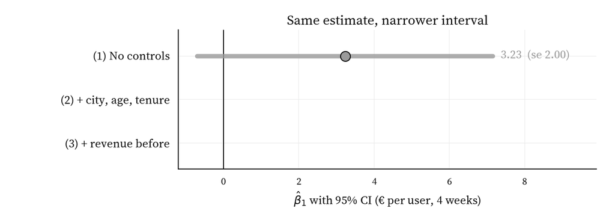

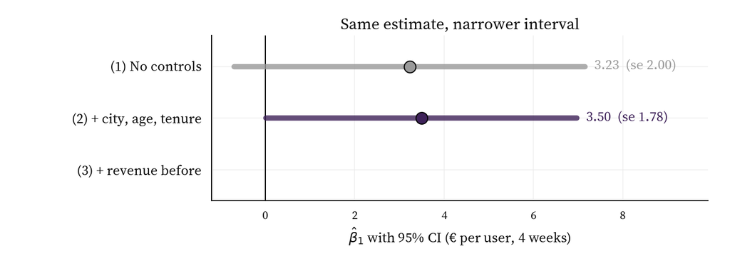

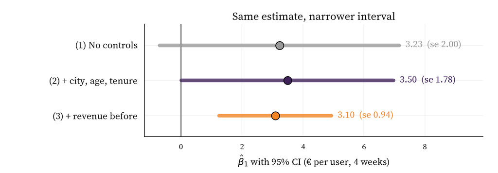

|  | (1) No controls | (2) + city, age, tenure | (3) + revenue before |
| --- | --- | --- | --- |
| $R^2$ | 0.001 | 0.218 | 0.781 |
| $p$-value of $\hat\beta_1$ | 0.107 | 0.049 | 0.001 |

- **Estimate barely moves:** $X \perp\!\!\!\perp D$ by design, so controlling for $X$ removes no bias (there is none), only chance imbalance.
- **SE shrinks:** past spending predicts future spending very well → less residual variance → **more precision / power**.
- Only **pre-treatment** covariates (never something the treatment could change).

## Heterogeneous treatment effects: by city

$$\texttt{revenue}\_\texttt{post}_i = \beta_0 + \beta_1 D_i + \textstyle\sum_{c \neq \text{Madrid}} \delta_c\,\text{city}_{c,i} + \sum_{c \neq \text{Madrid}} \theta_c\,(D_i \times \text{city}_{c,i}) + \varepsilon_i$$

OLS Regression Results

| Dep. Variable: | revenue_post | R-squared: | 0.176 |
| --- | --- | --- | --- |
| Model: | OLS | Adj. R-squared: | 0.175 |
| Method: | Least Squares | F-statistic: | 84.81 |
| Date: | Mon, 09 Nov 2026 | Prob (F-statistic): | 2.13e-115 |
| Time: | 21:08:31 | Log-Likelihood: | -21889. |
| No. Observations: | 4000 | AIC: | 4.379e+04 |
| Df Residuals: | 3992 | BIC: | 4.385e+04 |
| Df Model: | 7 |  |  |
| Covariance Type: | HC1 |  |  |

|  | coef | std err | z | P>\|z\| | [0.025 | 0.975] |
| --- | --- | --- | --- | --- | --- | --- |
| Intercept | 37.3973 | 1.534 | 24.372 | 0.000 | 34.390 | 40.405 |
| city[Barcelona] | 5.3419 | 2.245 | 2.380 | 0.017 | 0.942 | 9.742 |
| city[Paris] | 29.0204 | 3.455 | 8.400 | 0.000 | 22.249 | 35.791 |
| city[London] | 64.0574 | 4.710 | 13.601 | 0.000 | 54.827 | 73.288 |
| treat | -4.1250 | 2.024 | -2.038 | 0.042 | -8.092 | -0.158 |
| treat × city[Barcelona] | 8.1618 | 3.117 | 2.619 | 0.009 | 2.053 | 14.271 |
| treat × city[Paris] | 10.3056 | 4.790 | 2.151 | 0.031 | 0.917 | 19.694 |
| treat × city[London] | 14.3082 | 6.819 | 2.098 | 0.036 | 0.943 | 27.673 |

| Omnibus: | 1664.592 | Durbin-Watson: | 2.044 |
| --- | --- | --- | --- |
| Prob(Omnibus): | 0.000 | Jarque-Bera (JB): | 10530.678 |
| Skew: | 1.869 | Prob(JB): | 0.00 |
| Kurtosis: | 10.015 | Cond. No. | 11.9 |

Notes:  
[1] Standard Errors are heteroscedasticity robust (HC1)

## Heterogeneous treatment effects: by city

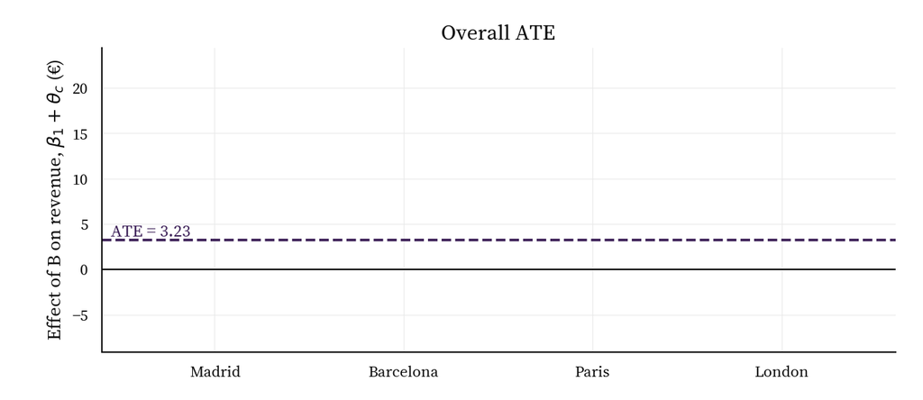

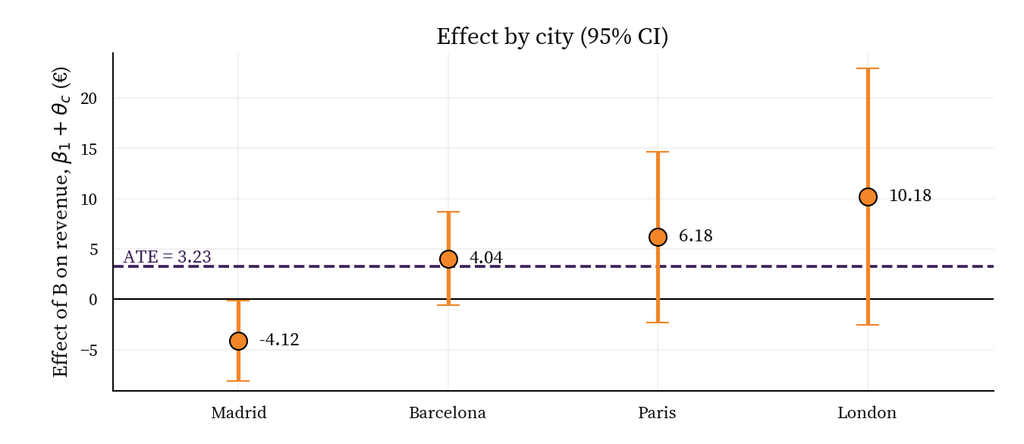

Joint test $H_0: \theta_{BCN} = \theta_{PAR} = \theta_{LON} = 0$: $F$ = 3.79, $p$ = 0.010 → we **reject** that the effect is the same in every city. Revenue rises most in **London** (€10.18) and **Paris** (€6.18). In **Madrid** the estimate is **negative**: users mostly switch to the cheaper option instead of riding more, so revenue falls. Randomization holds within each city, so each city effect is causal (but pre-specify subgroups: slice the data 20 ways and one will look significant by chance).

# Appendix

## Take-up: offering ≠ using

We can **offer** “Wait & Save” (app B), but we cannot force users to **choose** it.

| Users in B | N | Revenue **before** (€) | Revenue during (€) |
| --- | --- | --- | --- |
| Did not choose it | 1,239 | 40.71 | 45.25 |
| Chose it | 807 | 81.04 | 84.89 |

- Only **39%** of B users chose the new option.
- $\hat\beta_1$ = €3.10 is the effect of **being offered** the option: the **intention-to-treat (ITT)**. Still causal, and the relevant number for the launch decision.
- ❌ Don’t compare choosers vs non-choosers: choosers already spent much more **before** the test → self-selection, the same problem as smokers.
- Effect on those who actually chose it ≈ ITT / take-up = 3.10 / 0.39 = **€7.85** (more on this with IV, TA8).

## When SUTVA fails, change the unit of randomization

**SUTVA:** my outcome depends only on **my own** treatment, not on other users’ treatment.

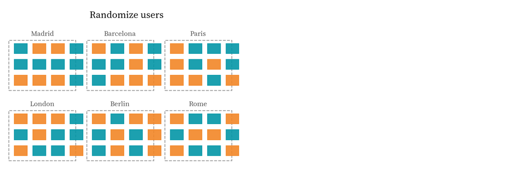

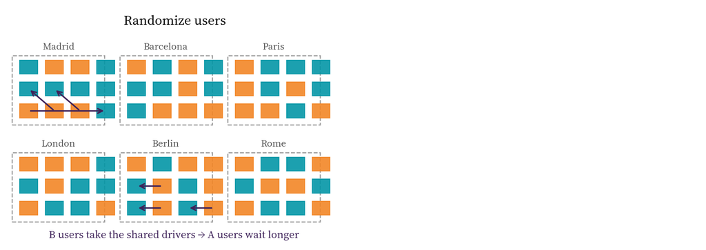

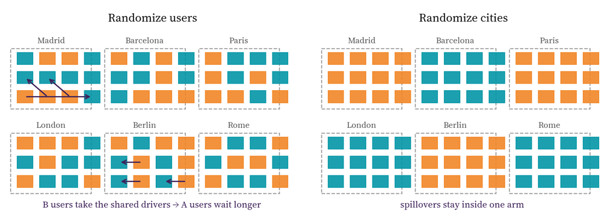

**How the spillover happens.** Users in the same city share the **same pool of drivers**. B users request extra (cheap) rides → fewer free drivers → **A users** wait longer, see surge prices, or give up → A’s revenue falls **because of B**. So $\bar Y_0$ no longer estimates $E[Y(0)]$, and $\bar Y_1 - \bar Y_0$ **overstates** the effect of launching the option for everyone.

**Fix:** randomize at the level where the interaction happens: the **city** (the driver market). All users in a city see the same app, so spillovers stay *within* one arm; **cluster SEs by city**. Cost: few units (cities) → much less power. In practice firms use many cities, or **switchback** designs (randomize city × time slot).